# 005 Purpose of Bias in a Neural Network

## Purpose of Bias in a Neural Network:

Let us create a Python code example to vividly demonstrate why biases are essential for a neural network, particularly for a neuron to output non-zero values even when all its inputs are zero, or to effectively shift its activation threshold.

### The Problem: Learning a Simple Constant Offset

Imagine we want a single "neuron" to learn a very simple task: always output a specific constant value, say `0.5`, regardless of its input. Or, more generally, to correctly classify data that is not centered at the origin.

**Scenario 1: Neuron WITHOUT Bias**

- **Formula:** `output = activation(weight * input)`
- If `input = 0`, then `output = activation(weight * 0) = activation(0)`.
  - If `activation` is ReLU, output is `0`.
  - If `activation` is Sigmoid, output is `0.5`.
  - This means a neuron without bias is always "anchored" to the origin (0,0) or (0,0.5) depending on the activation function. It cannot produce an arbitrary non-zero output when inputs are zero, nor can it shift its decision boundary.

**Scenario 2: Neuron WITH Bias**

- **Formula:** `output = activation(weight * input + bias)`
- If `input = 0`, then `output = activation(weight * 0 + bias) = activation(bias)`.
  - Now, if `bias` is, say, `1.0` and `activation` is Sigmoid, the output is `sigmoid(1.0) ≈ 0.73`.
  - This allows the neuron to produce a non-zero output when inputs are zero, or to activate even if the weighted input alone isn't strong enough. It effectively shifts the activation function's threshold.

### Explanation of Why Bias is Essential

Let's break down what the code demonstrates:

**The Problem Setup:**

- We're trying to make a single neuron predict `0.75` when its input `X` is `0.0`.
- We're using the `sigmoid` activation function, which outputs `0.5` when its input is `0`.

**Scenario 2: Neuron WITH Bias (`use_bias=True`)**

- **Model Formula:** `Output = sigmoid(weight * X + bias)`
- When `X = 0`, the input to the sigmoid function is `weight * 0 + bias = bias`.
- Therefore, `Output = sigmoid(bias)`.
- **Result:** Now, during training, the network can adjust the `bias` term. It will learn a `bias` value such that `sigmoid(bias)` is close to `0.75`. To get `sigmoid(x) = 0.75`, `x` needs to be approximately `1.098` (you can calculate this using `np.log(0.75 / (1 - 0.75))`). The neuron will try to learn a bias close to this value.
- **Visual:** In the plot, the "Final (With Bias)" line (blue) will adjust so that it passes through `(0, 0.75)`. The loss will drop much lower.

```python
import numpy as np
import matplotlib.pyplot as plt

# --- 1. Activation Function (Sigmoid) ---
def sigmoid(x):
    return 1 / (1 + np.exp(-x))

def sigmoid_derivative(x):
    s = sigmoid(x)
    return s * (1 - s)
```

```python
# --- 2. Loss Function (Mean Squared Error) ---
def mse_loss(y_pred, y_true):
    return np.mean((y_pred - y_true)**2)

# --- 3. Training Function ---
def train_neuron(X, y_true, initial_w, initial_b, learning_rate, epochs, use_bias=True, title_suffix=""):
    """
    Trains a single neuron with or without bias.
    """
    w = initial_w
    b = initial_b if use_bias else 0 # Bias is always 0 if not used
    loss_history = []

    # Store initial state for plotting
    w_initial = w
    b_initial = b if use_bias else 0

    print(f"\n--- Training Neuron {title_suffix} (Use Bias: {use_bias}) ---")
    print(f"Initial W: {w:.4f}, Initial B: {b:.4f}")

    for epoch in range(epochs):
        # Forward Pass
        # Z = w*X + b
        Z = w * X + b
        A = sigmoid(Z) # Neuron's output

        # Calculate Loss
        loss = mse_loss(A, y_true)
        loss_history.append(loss)

        # Backward Pass (Gradients)
        d_A = A - y_true # dLoss/dA
        d_Z = d_A * sigmoid_derivative(Z) # dLoss/dZ (chain rule: dLoss/dA * dA/dZ)

        # dW = dLoss/dZ * dZ/dW = dLoss/dZ * X
        dW = np.mean(d_Z * X) # Mean over samples

        # dB = dLoss/dZ * dZ/dB = dLoss/dZ * 1
        dB = np.mean(d_Z) # Mean over samples

        # Update Weights and Bias
        w = w - learning_rate * dW
        if use_bias:
            b = b - learning_rate * dB

        if epoch % (epochs // 5) == 0:
            print(f"Epoch {epoch:4d} | Loss: {loss:.4f} | Current W: {w:.4f} | Current B: {b:.4f}")

    print(f"Epoch {epochs-1:4d} | Loss: {loss:.4f} | Final W: {w:.4f} | Final B: {b:.4f}")
    return w, b, loss_history, w_initial, b_initial
```

```python
# --- 4. Define Training Data and Target ---
X_train = np.array([[0.0]]) # Input is always 0
y_target = np.array([[0.75]]) # Target output is 0.75

learning_rate = 0.5
epochs = 5000
```

```python
# --- 5. Train Neuron WITHOUT Bias ---
final_w_no_bias, final_b_no_bias, loss_hist_no_bias, \
    initial_w_no_bias, initial_b_no_bias = train_neuron(
    X_train, y_target, initial_w=0.1, initial_b=0.0,
    learning_rate=learning_rate, epochs=epochs, use_bias=False, title_suffix="WITHOUT Bias"
)
```

```
--- Training Neuron WITHOUT Bias (Use Bias: False) ---
Initial W: 0.1000, Initial B: 0.0000
Epoch    0 | Loss: 0.0625 | Current W: 0.1000 | Current B: 0.0000
Epoch 1000 | Loss: 0.0625 | Current W: 0.1000 | Current B: 0.0000
Epoch 2000 | Loss: 0.0625 | Current W: 0.1000 | Current B: 0.0000
Epoch 3000 | Loss: 0.0625 | Current W: 0.1000 | Current B: 0.0000
Epoch 4000 | Loss: 0.0625 | Current W: 0.1000 | Current B: 0.0000
Epoch 4999 | Loss: 0.0625 | Final W: 0.1000 | Final B: 0.0000
```

```python
# --- 6. Train Neuron WITH Bias ---
final_w_with_bias, final_b_with_bias, loss_hist_with_bias, \
    initial_w_with_bias, initial_b_with_bias = train_neuron(
    X_train, y_target, initial_w=0.1, initial_b=0.0, # Initial bias can be 0, it will learn
    learning_rate=learning_rate, epochs=epochs, use_bias=True, title_suffix="WITH Bias"
)
```

```
--- Training Neuron WITH Bias (Use Bias: True) ---
Initial W: 0.1000, Initial B: 0.0000
Epoch    0 | Loss: 0.0625 | Current W: 0.1000 | Current B: 0.0312
Epoch 1000 | Loss: 0.0000 | Current W: 0.1000 | Current B: 1.0986
Epoch 2000 | Loss: 0.0000 | Current W: 0.1000 | Current B: 1.0986
Epoch 3000 | Loss: 0.0000 | Current W: 0.1000 | Current B: 1.0986
Epoch 4000 | Loss: 0.0000 | Current W: 0.1000 | Current B: 1.0986
Epoch 4999 | Loss: 0.0000 | Final W: 0.1000 | Final B: 1.0986
```

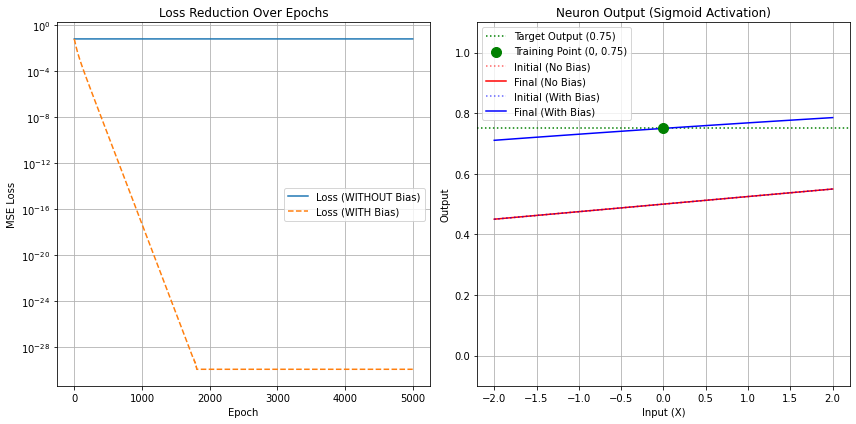

```python
# --- 7. Visualization ---

plt.figure(figsize=(12, 6))

# Plot Loss History
plt.subplot(1, 2, 1)
plt.plot(loss_hist_no_bias, label='Loss (WITHOUT Bias)')
plt.plot(loss_hist_with_bias, label='Loss (WITH Bias)', linestyle='--')
plt.title('Loss Reduction Over Epochs')
plt.xlabel('Epoch')
plt.ylabel('MSE Loss')
plt.legend()
plt.grid(True)
plt.yscale('log') # Log scale helps visualize large initial drops

# Plot Neuron Output vs. Input for both cases
# Let's plot the output for a range of inputs to see the learned function
input_range = np.linspace(-2, 2, 100).reshape(-1, 1)

output_no_bias_initial = sigmoid(initial_w_no_bias * input_range + initial_b_no_bias)
output_no_bias_final = sigmoid(final_w_no_bias * input_range + final_b_no_bias)

output_with_bias_initial = sigmoid(initial_w_with_bias * input_range + initial_b_with_bias)
output_with_bias_final = sigmoid(final_w_with_bias * input_range + final_b_with_bias)


plt.subplot(1, 2, 2)
plt.axhline(y_target[0][0], color='green', linestyle=':', label=f'Target Output ({y_target[0][0]})')
plt.scatter(X_train, y_target, color='green', marker='o', s=100, zorder=5, label='Training Point (0, 0.75)')

plt.plot(input_range, output_no_bias_initial, 'r:', alpha=0.6, label='Initial (No Bias)')
plt.plot(input_range, output_no_bias_final, 'r-', label='Final (No Bias)')

plt.plot(input_range, output_with_bias_initial, 'b:', alpha=0.6, label='Initial (With Bias)')
plt.plot(input_range, output_with_bias_final, 'b-', label='Final (With Bias)')


plt.title('Neuron Output (Sigmoid Activation)')
plt.xlabel('Input (X)')
plt.ylabel('Output')
plt.ylim(-0.1, 1.1)
plt.legend()
plt.grid(True)

plt.tight_layout()
plt.show()
```

```python
# --- Conclusion ---
print("\n--- Why Bias is Required ---")
print(f"Target Output for Input=0: {y_target[0][0]}")

print(f"\nNeuron WITHOUT Bias:")
print(f"  Initial Output at X=0: {sigmoid(initial_w_no_bias * 0 + initial_b_no_bias):.4f}")
print(f"  Final Output at X=0: {sigmoid(final_w_no_bias * 0 + final_b_no_bias):.4f}")
print("  Observations: The output for X=0 is always fixed at sigmoid(0)=0.5, regardless of the weight.")
print("  It CANNOT learn to output 0.75 when input is 0, because it is forced to pass through sigmoid(0).")

print(f"\nNeuron WITH Bias:")
print(f"  Initial Output at X=0: {sigmoid(initial_w_with_bias * 0 + initial_b_with_bias):.4f}")
print(f"  Final Output at X=0: {sigmoid(final_w_with_bias * 0 + final_b_with_bias):.4f}")
print("  Observations: The bias term allows the neuron to shift its activation. It learns a bias value")
print(f"  (approx. {final_b_with_bias:.4f}) such that sigmoid({final_b_with_bias:.4f}) is close to {y_target[0][0]}.")
print("  It CAN learn to output 0.75 because the bias provides an adjustable offset to the weighted sum.")

print("\nIn summary: Without bias, the activation function's output is always 'anchored' to 0 (or 0.5 for sigmoid) when inputs are 0.")
print("Bias allows the neuron to produce a non-zero output when inputs are 0, or to effectively shift the activation threshold,")
print("making the model more flexible and capable of fitting a wider range of data patterns, especially when data is not centered at the origin.")
```

```
--- Why Bias is Required ---
Target Output for Input=0: 0.75

Neuron WITHOUT Bias:
  Initial Output at X=0: 0.5000
  Final Output at X=0: 0.5000
  Observations: The output for X=0 is always fixed at sigmoid(0)=0.5, regardless of the weight.
  It CANNOT learn to output 0.75 when input is 0, because it is forced to pass through sigmoid(0).

Neuron WITH Bias:
  Initial Output at X=0: 0.5000
  Final Output at X=0: 0.7500
  Observations: The bias term allows the neuron to shift its activation. It learns a bias value
  (approx. 1.0986) such that sigmoid(1.0986) is close to 0.75.
  It CAN learn to output 0.75 because the bias provides an adjustable offset to the weighted sum.

In summary: Without bias, the activation function's output is always 'anchored' to 0 (or 0.5 for sigmoid) when inputs are 0.
Bias allows the neuron to produce a non-zero output when inputs are 0, or to effectively shift the activation threshold,
making the model more flexible and capable of fitting a wider range of data patterns, especially when data is not centered at the origin.
```

### Why Bias is Crucial:

1. **Shifting the Activation Threshold/Decision Boundary:**
   - The bias term allows the activation function to be "shifted" along the x-axis (the input axis to the activation function).
   - Without a bias, the neuron's activation (and thus its output) is always centered around 0 when its weighted input is 0.
   - With a bias, the neuron can output a non-zero value even when all its inputs are zero. This is vital for models that need to activate regardless of specific input features, or for tasks where the decision boundary does not pass through the origin.
   - In the example, the `sigmoid(bias)` allows the neuron to produce `0.75` for `X=0`, which `sigmoid(0)` (without bias) could not do.
1. **Increased Model Flexibility:**
   - Bias effectively allows the model to learn a constant offset or baseline. It's like providing the neuron with its own inherent tendency to activate (or not activate) before any actual input comes in.
   - This makes the model much more flexible and capable of fitting a wider variety of functions and data distributions, especially when data is not centered around the origin.

In essence, **weights determine the slope or magnitude of the input's influence, while biases determine the "offset" or "intercept" that shifts the entire activation.**

Without biases, neural networks would be severely limited in the types of functions they could learn, particularly in scenarios where the desired output is non-zero for zero inputs or where the decision boundaries are not at the origin.